# Explore_bikeshare_data

### Explore Bike Share Data

For this project, your goal is to ask and answer three questions about the available bikeshare data from Washington, Chicago, and New York. This notebook can be submitted directly through the workspace when you are confident in your results.

You will be graded against the project [Rubric](https://review.udacity.com/#!/rubrics/2508/view) by a mentor after you have submitted. To get you started, you can use the template below, but feel free to be creative in your solutions!

```r
library(ggplot2)
library(dplyr)
```

```r
ny = read.csv('new_york_city.csv')
wash = read.csv('washington.csv')
chi = read.csv('chicago.csv')
```

```r
head(ny)
```

| X | Start.Time | End.Time | Trip.Duration | Start.Station | End.Station | User.Type | Gender | Birth.Year |
| --- | --- | --- | --- | --- | --- | --- | --- | --- |
| 5688089 | 2017-06-11 14:55:05 | 2017-06-11 15:08:21 | 795 | Suffolk St & Stanton St | W Broadway & Spring St | Subscriber | Male | 1998 |
| 4096714 | 2017-05-11 15:30:11 | 2017-05-11 15:41:43 | 692 | Lexington Ave & E 63 St | 1 Ave & E 78 St | Subscriber | Male | 1981 |
| 2173887 | 2017-03-29 13:26:26 | 2017-03-29 13:48:31 | 1325 | 1 Pl & Clinton St | Henry St & Degraw St | Subscriber | Male | 1987 |
| 3945638 | 2017-05-08 19:47:18 | 2017-05-08 19:59:01 | 703 | Barrow St & Hudson St | W 20 St & 8 Ave | Subscriber | Female | 1986 |
| 6208972 | 2017-06-21 07:49:16 | 2017-06-21 07:54:46 | 329 | 1 Ave & E 44 St | E 53 St & 3 Ave | Subscriber | Male | 1992 |
| 1285652 | 2017-02-22 18:55:24 | 2017-02-22 19:12:03 | 998 | State St & Smith St | Bond St & Fulton St | Subscriber | Male | 1986 |

```r
str(ny)
```

```
'data.frame':	54770 obs. of  9 variables:
 $ X            : int  5688089 4096714 2173887 3945638 6208972 1285652 1675753 1692245 2271331 1558339 ...
 $ Start.Time   : Factor w/ 54568 levels "2017-01-01 00:17:01",..: 45448 32799 17316 31589 49688 10220 13390 13509 18111 12449 ...
 $ End.Time     : Factor w/ 54562 levels "201","2017-01-01 00:30:56",..: 45432 32783 17295 31567 49668 10204 13364 13505 18092 12422 ...
 $ Trip.Duration: int  795 692 1325 703 329 998 478 4038 5132 309 ...
 $ Start.Station: Factor w/ 636 levels "","1 Ave & E 16 St",..: 522 406 10 93 5 521 325 309 151 245 ...
 $ End.Station  : Factor w/ 638 levels "","1 Ave & E 16 St",..: 613 8 362 558 269 107 389 110 151 243 ...
 $ User.Type    : Factor w/ 3 levels "","Customer",..: 3 3 3 3 3 3 3 3 2 3 ...
 $ Gender       : Factor w/ 3 levels "","Female","Male": 3 3 3 2 3 3 3 3 1 3 ...
 $ Birth.Year   : num  1998 1981 1987 1986 1992 ...
```

```r
head(wash)
```

| X | Start.Time | End.Time | Trip.Duration | Start.Station | End.Station | User.Type |
| --- | --- | --- | --- | --- | --- | --- |
| 1621326 | 2017-06-21 08:36:34 | 2017-06-21 08:44:43 | 489.066 | 14th & Belmont St NW | 15th & K St NW | Subscriber |
| 482740 | 2017-03-11 10:40:00 | 2017-03-11 10:46:00 | 402.549 | Yuma St & Tenley Circle NW | Connecticut Ave & Yuma St NW | Subscriber |
| 1330037 | 2017-05-30 01:02:59 | 2017-05-30 01:13:37 | 637.251 | 17th St & Massachusetts Ave NW | 5th & K St NW | Subscriber |
| 665458 | 2017-04-02 07:48:35 | 2017-04-02 08:19:03 | 1827.341 | Constitution Ave & 2nd St NW/DOL | M St & Pennsylvania Ave NW | Customer |
| 1481135 | 2017-06-10 08:36:28 | 2017-06-10 09:02:17 | 1549.427 | Henry Bacon Dr & Lincoln Memorial Circle NW | Maine Ave & 7th St SW | Subscriber |
| 1148202 | 2017-05-14 07:18:18 | 2017-05-14 07:24:56 | 398.000 | 1st & K St SE | Eastern Market Metro / Pennsylvania Ave & 7th St SE | Subscriber |

```r
str(wash)
```

```
'data.frame':	89051 obs. of  7 variables:
 $ X            : int  1621326 482740 1330037 665458 1481135 1148202 1594275 1601832 574182 327058 ...
 $ Start.Time   : Factor w/ 81223 levels "","2017-01-01 00:11:00",..: 74753 19510 59964 26708 67716 50891 73381 73775 23142 13333 ...
 $ End.Time     : Factor w/ 81217 levels "","2017-01-01 00:14:00",..: 74744 19473 59981 26732 67753 50918 73397 73775 23114 13350 ...
 $ Trip.Duration: num  489 403 637 1827 1549 ...
 $ Start.Station: Factor w/ 478 levels "","10th & E St NW",..: 27 478 66 221 278 84 368 82 71 60 ...
 $ End.Station  : Factor w/ 479 levels "","10th & E St NW",..: 47 219 144 312 315 239 162 376 51 308 ...
 $ User.Type    : Factor w/ 3 levels "","Customer",..: 3 3 3 2 3 3 3 3 3 3 ...
```

```r
head(chi)
```

| X | Start.Time | End.Time | Trip.Duration | Start.Station | End.Station | User.Type | Gender | Birth.Year |
| --- | --- | --- | --- | --- | --- | --- | --- | --- |
| 1423854 | 2017-06-23 15:09:32 | 2017-06-23 15:14:53 | 321 | Wood St & Hubbard St | Damen Ave & Chicago Ave | Subscriber | Male | 1992 |
| 955915 | 2017-05-25 18:19:03 | 2017-05-25 18:45:53 | 1610 | Theater on the Lake | Sheffield Ave & Waveland Ave | Subscriber | Female | 1992 |
| 9031 | 2017-01-04 08:27:49 | 2017-01-04 08:34:45 | 416 | May St & Taylor St | Wood St & Taylor St | Subscriber | Male | 1981 |
| 304487 | 2017-03-06 13:49:38 | 2017-03-06 13:55:28 | 350 | Christiana Ave & Lawrence Ave | St. Louis Ave & Balmoral Ave | Subscriber | Male | 1986 |
| 45207 | 2017-01-17 14:53:07 | 2017-01-17 15:02:01 | 534 | Clark St & Randolph St | Desplaines St & Jackson Blvd | Subscriber | Male | 1975 |
| 1473887 | 2017-06-26 09:01:20 | 2017-06-26 09:11:06 | 586 | Clinton St & Washington Blvd | Canal St & Taylor St | Subscriber | Male | 1990 |

```r
str(chi)
```

```
'data.frame':	8630 obs. of  9 variables:
 $ X            : int  1423854 955915 9031 304487 45207 1473887 961916 65924 606841 135470 ...
 $ Start.Time   : Factor w/ 8624 levels "2017-01-01 00:40:14",..: 7876 5303 73 1721 267 8173 5347 368 3376 795 ...
 $ End.Time     : Factor w/ 8625 levels "2017-01-01 00:46:32",..: 7876 5303 73 1722 267 8173 5346 368 3376 796 ...
 $ Trip.Duration: int  321 1610 416 350 534 586 281 723 689 493 ...
 $ Start.Station: Factor w/ 472 levels "2112 W Peterson Ave",..: 468 424 291 80 103 119 22 255 374 420 ...
 $ End.Station  : Factor w/ 471 levels "","2112 W Peterson Ave",..: 132 381 469 409 151 70 467 251 200 118 ...
 $ User.Type    : Factor w/ 3 levels "","Customer",..: 3 3 3 3 3 3 3 2 3 3 ...
 $ Gender       : Factor w/ 3 levels "","Female","Male": 3 2 3 3 3 3 2 1 3 3 ...
 $ Birth.Year   : num  1992 1992 1981 1986 1975 ...
```

### Data Wrangling

Before I begin exploring the data, I am going to combine the three cities into one dataframe to make it easier to work with.

First, I need to add the Gender and Birth.Year columns to the Washington data. The columns will be null, but it will allow me to combine the data.

```r
#Define empty variable
new <- NA

#Add empty Gender column to wash
wash['Gender'] <- new

#Add empty Birth.Year column to wash
wash['Birth.Year'] <- new
```

```r
head(wash)
```

| X | Start.Time | End.Time | Trip.Duration | Start.Station | End.Station | User.Type | Gender | Birth.Year |
| --- | --- | --- | --- | --- | --- | --- | --- | --- |
| 1621326 | 2017-06-21 08:36:34 | 2017-06-21 08:44:43 | 489.066 | 14th & Belmont St NW | 15th & K St NW | Subscriber | NA | NA |
| 482740 | 2017-03-11 10:40:00 | 2017-03-11 10:46:00 | 402.549 | Yuma St & Tenley Circle NW | Connecticut Ave & Yuma St NW | Subscriber | NA | NA |
| 1330037 | 2017-05-30 01:02:59 | 2017-05-30 01:13:37 | 637.251 | 17th St & Massachusetts Ave NW | 5th & K St NW | Subscriber | NA | NA |
| 665458 | 2017-04-02 07:48:35 | 2017-04-02 08:19:03 | 1827.341 | Constitution Ave & 2nd St NW/DOL | M St & Pennsylvania Ave NW | Customer | NA | NA |
| 1481135 | 2017-06-10 08:36:28 | 2017-06-10 09:02:17 | 1549.427 | Henry Bacon Dr & Lincoln Memorial Circle NW | Maine Ave & 7th St SW | Subscriber | NA | NA |
| 1148202 | 2017-05-14 07:18:18 | 2017-05-14 07:24:56 | 398.000 | 1st & K St SE | Eastern Market Metro / Pennsylvania Ave & 7th St SE | Subscriber | NA | NA |

I also need to add a City column to each dataset so I know which city each record came from.

```r
ny['City'] <- 'New York City'
wash['City'] <- 'Washington'
chi['City'] <- 'Chicago'
```

```r
head(ny)
```

| X | Start.Time | End.Time | Trip.Duration | Start.Station | End.Station | User.Type | Gender | Birth.Year | City |
| --- | --- | --- | --- | --- | --- | --- | --- | --- | --- |
| 5688089 | 2017-06-11 14:55:05 | 2017-06-11 15:08:21 | 795 | Suffolk St & Stanton St | W Broadway & Spring St | Subscriber | Male | 1998 | New York City |
| 4096714 | 2017-05-11 15:30:11 | 2017-05-11 15:41:43 | 692 | Lexington Ave & E 63 St | 1 Ave & E 78 St | Subscriber | Male | 1981 | New York City |
| 2173887 | 2017-03-29 13:26:26 | 2017-03-29 13:48:31 | 1325 | 1 Pl & Clinton St | Henry St & Degraw St | Subscriber | Male | 1987 | New York City |
| 3945638 | 2017-05-08 19:47:18 | 2017-05-08 19:59:01 | 703 | Barrow St & Hudson St | W 20 St & 8 Ave | Subscriber | Female | 1986 | New York City |
| 6208972 | 2017-06-21 07:49:16 | 2017-06-21 07:54:46 | 329 | 1 Ave & E 44 St | E 53 St & 3 Ave | Subscriber | Male | 1992 | New York City |
| 1285652 | 2017-02-22 18:55:24 | 2017-02-22 19:12:03 | 998 | State St & Smith St | Bond St & Fulton St | Subscriber | Male | 1986 | New York City |

```r
head(wash)
```

| X | Start.Time | End.Time | Trip.Duration | Start.Station | End.Station | User.Type | Gender | Birth.Year | City |
| --- | --- | --- | --- | --- | --- | --- | --- | --- | --- |
| 1621326 | 2017-06-21 08:36:34 | 2017-06-21 08:44:43 | 489.066 | 14th & Belmont St NW | 15th & K St NW | Subscriber | NA | NA | Washington |
| 482740 | 2017-03-11 10:40:00 | 2017-03-11 10:46:00 | 402.549 | Yuma St & Tenley Circle NW | Connecticut Ave & Yuma St NW | Subscriber | NA | NA | Washington |
| 1330037 | 2017-05-30 01:02:59 | 2017-05-30 01:13:37 | 637.251 | 17th St & Massachusetts Ave NW | 5th & K St NW | Subscriber | NA | NA | Washington |
| 665458 | 2017-04-02 07:48:35 | 2017-04-02 08:19:03 | 1827.341 | Constitution Ave & 2nd St NW/DOL | M St & Pennsylvania Ave NW | Customer | NA | NA | Washington |
| 1481135 | 2017-06-10 08:36:28 | 2017-06-10 09:02:17 | 1549.427 | Henry Bacon Dr & Lincoln Memorial Circle NW | Maine Ave & 7th St SW | Subscriber | NA | NA | Washington |
| 1148202 | 2017-05-14 07:18:18 | 2017-05-14 07:24:56 | 398.000 | 1st & K St SE | Eastern Market Metro / Pennsylvania Ave & 7th St SE | Subscriber | NA | NA | Washington |

```r
head(chi)
```

| X | Start.Time | End.Time | Trip.Duration | Start.Station | End.Station | User.Type | Gender | Birth.Year | City |
| --- | --- | --- | --- | --- | --- | --- | --- | --- | --- |
| 1423854 | 2017-06-23 15:09:32 | 2017-06-23 15:14:53 | 321 | Wood St & Hubbard St | Damen Ave & Chicago Ave | Subscriber | Male | 1992 | Chicago |
| 955915 | 2017-05-25 18:19:03 | 2017-05-25 18:45:53 | 1610 | Theater on the Lake | Sheffield Ave & Waveland Ave | Subscriber | Female | 1992 | Chicago |
| 9031 | 2017-01-04 08:27:49 | 2017-01-04 08:34:45 | 416 | May St & Taylor St | Wood St & Taylor St | Subscriber | Male | 1981 | Chicago |
| 304487 | 2017-03-06 13:49:38 | 2017-03-06 13:55:28 | 350 | Christiana Ave & Lawrence Ave | St. Louis Ave & Balmoral Ave | Subscriber | Male | 1986 | Chicago |
| 45207 | 2017-01-17 14:53:07 | 2017-01-17 15:02:01 | 534 | Clark St & Randolph St | Desplaines St & Jackson Blvd | Subscriber | Male | 1975 | Chicago |
| 1473887 | 2017-06-26 09:01:20 | 2017-06-26 09:11:06 | 586 | Clinton St & Washington Blvd | Canal St & Taylor St | Subscriber | Male | 1990 | Chicago |

Since I am going to concatenate data a few times, I am going to create a function to make my life easier.

```r
#Create function that binds df2 to df1
concat <- function(df1, df2){
    return(rbind(df1, df2))
}
```

Let's combine the data into one dataframe called df_cities.

```r
#Call concat function to bind wash to ny
df_cities <- concat(ny, wash)

#Call concat function to bind chi to df_cities
df_cities <- concat(df_cities, chi)
```

```r
head(df_cities)
```

| X | Start.Time | End.Time | Trip.Duration | Start.Station | End.Station | User.Type | Gender | Birth.Year | City |
| --- | --- | --- | --- | --- | --- | --- | --- | --- | --- |
| 5688089 | 2017-06-11 14:55:05 | 2017-06-11 15:08:21 | 795 | Suffolk St & Stanton St | W Broadway & Spring St | Subscriber | Male | 1998 | New York City |
| 4096714 | 2017-05-11 15:30:11 | 2017-05-11 15:41:43 | 692 | Lexington Ave & E 63 St | 1 Ave & E 78 St | Subscriber | Male | 1981 | New York City |
| 2173887 | 2017-03-29 13:26:26 | 2017-03-29 13:48:31 | 1325 | 1 Pl & Clinton St | Henry St & Degraw St | Subscriber | Male | 1987 | New York City |
| 3945638 | 2017-05-08 19:47:18 | 2017-05-08 19:59:01 | 703 | Barrow St & Hudson St | W 20 St & 8 Ave | Subscriber | Female | 1986 | New York City |
| 6208972 | 2017-06-21 07:49:16 | 2017-06-21 07:54:46 | 329 | 1 Ave & E 44 St | E 53 St & 3 Ave | Subscriber | Male | 1992 | New York City |
| 1285652 | 2017-02-22 18:55:24 | 2017-02-22 19:12:03 | 998 | State St & Smith St | Bond St & Fulton St | Subscriber | Male | 1986 | New York City |

```r
tail(df_cities)
```

|  | X | Start.Time | End.Time | Trip.Duration | Start.Station | End.Station | User.Type | Gender | Birth.Year | City |
| --- | --- | --- | --- | --- | --- | --- | --- | --- | --- | --- |
| 152446 | 397518 | 2017-03-24 16:52:16 | 2017-03-24 16:57:57 | 341 | Southport Ave & Waveland Ave | Southport Ave & Waveland Ave | Subscriber | Male | 1990 | Chicago |
| 152447 | 879494 | 2017-05-18 05:06:50 | 2017-05-18 05:22:10 | 920 | Artesian Ave & Hubbard St | Wacker Dr & Washington St | Subscriber | Male | 1959 | Chicago |
| 152448 | 360389 | 2017-03-19 07:21:29 | 2017-03-19 07:27:18 | 349 | Wabash Ave & Roosevelt Rd | Wells St & Polk St | Subscriber | Male | 1987 | Chicago |
| 152449 | 858496 | 2017-05-16 17:03:24 | 2017-05-16 17:31:12 | 1668 | Ashland Ave & Harrison St | Wells St & Concord Ln | Subscriber | Male | 1963 | Chicago |
| 152450 | 777620 | 2017-05-10 08:53:03 | 2017-05-10 08:54:32 | 89 | Western Ave & Leland Ave | Western Ave & Leland Ave | Subscriber | Male | 1977 | Chicago |
| 152451 | 1230561 | 2017-06-11 14:52:13 | 2017-06-11 15:42:33 | 3020 | Waba |  |  |  | NA | Chicago |

```r
str(df_cities)
```

```
'data.frame':	152451 obs. of  10 variables:
 $ X            : int  5688089 4096714 2173887 3945638 6208972 1285652 1675753 1692245 2271331 1558339 ...
 $ Start.Time   : Factor w/ 143945 levels "2017-01-01 00:17:01",..: 45448 32799 17316 31589 49688 10220 13390 13509 18111 12449 ...
 $ End.Time     : Factor w/ 143948 levels "201","2017-01-01 00:30:56",..: 45432 32783 17295 31567 49668 10204 13364 13505 18092 12422 ...
 $ Trip.Duration: num  795 692 1325 703 329 ...
 $ Start.Station: Factor w/ 1585 levels "","1 Ave & E 16 St",..: 522 406 10 93 5 521 325 309 151 245 ...
 $ End.Station  : Factor w/ 1586 levels "","1 Ave & E 16 St",..: 613 8 362 558 269 107 389 110 151 243 ...
 $ User.Type    : Factor w/ 3 levels "","Customer",..: 3 3 3 3 3 3 3 3 2 3 ...
 $ Gender       : Factor w/ 3 levels "","Female","Male": 3 3 3 2 3 3 3 3 1 3 ...
 $ Birth.Year   : num  1998 1981 1987 1986 1992 ...
 $ City         : chr  "New York City" "New York City" "New York City" "New York City" ...
```

```r
summary(df_cities)
```

```
       X                         Start.Time                    End.Time
 Min.   :      7   2017-02-19 12:19:00:     6   2017-03-09 17:54:00:     7
 1st Qu.: 589310   2017-02-20 11:35:00:     6   2017-03-28 18:11:00:     7
 Median :1184899   2017-02-24 17:46:00:     6   2017-01-13 17:48:00:     6
 Mean   :1781625   2017-03-01 08:20:00:     6   2017-01-31 08:49:00:     6
 3rd Qu.:2085970   2017-03-02 08:39:00:     6   2017-02-13 18:09:00:     6
 Max.   :6816152   2017-03-09 17:31:00:     6   2017-02-20 11:38:00:     6
                   (Other)            :152415   (Other)            :152413
 Trip.Duration                                  Start.Station
 Min.   :     60   Columbus Circle / Union Station     :  1700
 1st Qu.:    392   Lincoln Memorial                    :  1546
 Median :    667   Jefferson Dr & 14th St SW           :  1488
 Mean   :   1098   Massachusetts Ave & Dupont Circle NW:  1219
 3rd Qu.:   1159   Jefferson Memorial                  :  1068
 Max.   :1088634   15th & P St NW                      :  1040
 NA's   :2         (Other)                             :144390
                                                End.Station
 Columbus Circle / Union Station                      :  1767
 Jefferson Dr & 14th St SW                            :  1603
 Lincoln Memorial                                     :  1514
 Massachusetts Ave & Dupont Circle NW                 :  1344
 Smithsonian-National Mall / Jefferson Dr & 12th St SW:  1103
 15th & P St NW                                       :  1077
 (Other)                                              :144043
      User.Type         Gender        Birth.Year        City
           :   121         : 7158   Min.   :1885    Length:152451
 Customer  : 30754   Female:13882   1st Qu.:1970    Class :character
 Subscriber:121576   Male  :42360   Median :1981    Mode  :character
                     NA's  :89051   Mean   :1979
                                    3rd Qu.:1988
                                    Max.   :2002
                                    NA's   :96016
```

### Question 1

**What is the average trip duration in each city?**

First, let's find the average trip duration in each city.

```r
#Find average trip duration using group_by()
avg_table <- df_cities %>%
    group_by(City) %>%
        summarise(avg_duration = mean(Trip.Duration, na.rm = TRUE))

avg_table
```

| City | avg_duration |
| --- | --- |
| Chicago | 937.1728 |
| New York City | 903.6147 |
| Washington | 1233.9533 |

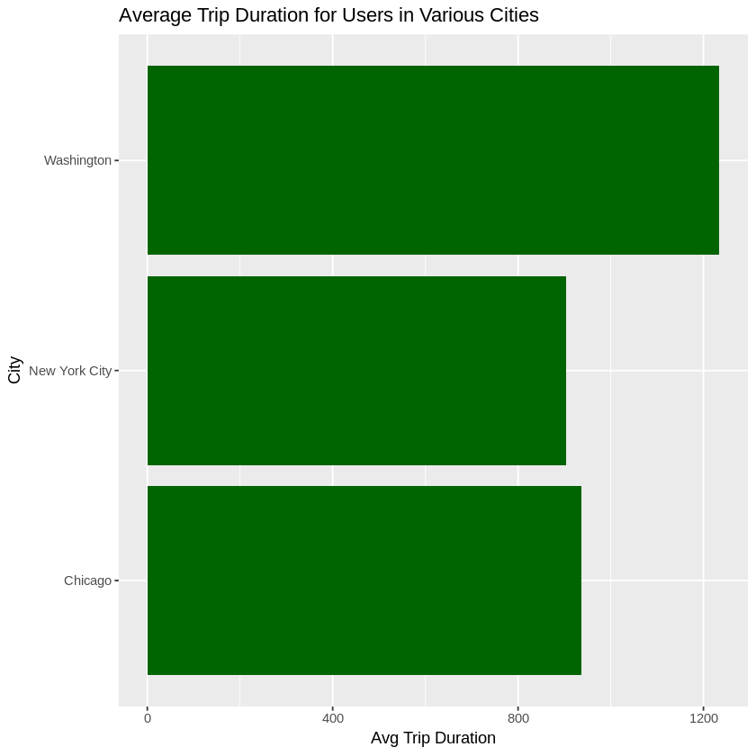

```r
#Visualize average trip duration data
ggplot(aes(x = City, y = avg_duration), data = avg_table) +
    geom_bar(stat = 'summary', fun.y = 'mean', fill = 'dark green') +
    ggtitle('Average Trip Duration for Users in Various Cities') +
    labs(y = 'Avg Trip Duration', x = 'City') +
    coord_flip()
```

**Summary of your question 1 results goes here.**

Here we can see that the average trip duration in Chicago is 937.1728 seconds, New York City is 903.6147 seconds, and Washington is 1233.9533 seconds. Washington is far ahead in average trip duration, while Chicago and New York City are pretty close.

### Question 2

**What are the counts of each gender in New York City and Chicago?**

Washington does not include gender data, so I am going to use my concat function from earlier to create a new dataframe that only includes New York City and Chicago.

```r
#Create new dataframe by using concat() function
df_gender <- concat(ny, chi)
```

```r
df_gender
```

[output not shown]

```r
#Find rider gender counts using group_by()
gender_table <- df_gender %>%
    group_by(Gender, City) %>%
        summarise(gender_count = n())
gender_table
```

| Gender | City | gender_count |
| --- | --- | --- |
|  | Chicago | 1748 |
|  | New York City | 5410 |
| Female | Chicago | 1723 |
| Female | New York City | 12159 |
| Male | Chicago | 5159 |
| Male | New York City | 37201 |

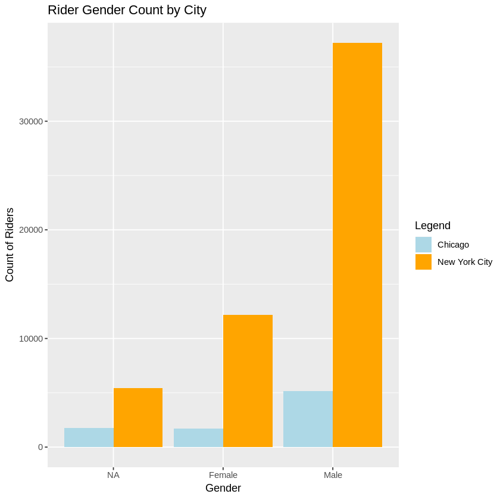

```r
#Visualize rider gender count data
ggplot(aes(x = Gender, fill = City), data = df_gender) +
    geom_bar(position = 'dodge') +
    ggtitle('Rider Gender Count by City') +
    scale_x_discrete(labels = c('NA', 'Female', 'Male')) +
    labs(y = 'Count of Riders', x = 'Gender') +
    scale_fill_manual('Legend', values = c('Chicago' = 'light blue', 'New York City' = 'orange'))
```

**Summary of your question 2 results goes here.**

As seen in the table above, Chicago has 1748 riders without gender data, 1723 female riders, and 5159 male riders. New York City has 5410 riders without gender data, 12159 female riders, and 37201 male riders. I do not think comparing the rider count by city is very useful. New York City has far more riders than Chicago, and simply counting the gender of riders in each city does not tell us much.

### Question 3

**What does the percentage of each gender look like in New York City vs. Chicago?**

As a follow up to the previous question, let's compare the percentages of each gender across the city. This will provide a better insight than a simple count. We will use the gender_table that we created in the last question because it already contains the cleaned data we need.

```r
#Find rider gender percentages using group_by()
gender_percent_table <- gender_table %>%
    group_by(City) %>%
        mutate(total_count = sum(gender_count)) %>%
            group_by(Gender, add = TRUE) %>%
                mutate(percent = round(100*gender_count/total_count,2))
gender_percent_table
```

| Gender | City | gender_count | total_count | percent |
| --- | --- | --- | --- | --- |
|  | Chicago | 1748 | 8630 | 20.25 |
|  | New York City | 5410 | 54770 | 9.88 |
| Female | Chicago | 1723 | 8630 | 19.97 |
| Female | New York City | 12159 | 54770 | 22.20 |
| Male | Chicago | 5159 | 8630 | 59.78 |
| Male | New York City | 37201 | 54770 | 67.92 |

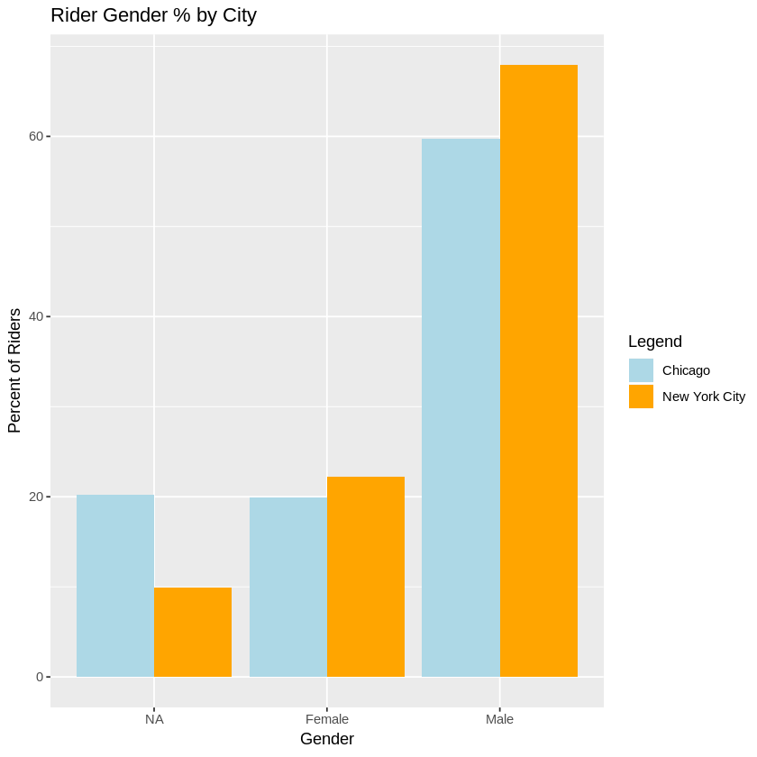

```r
#Visualize rider gender percentage data
ggplot(aes(x = Gender, y = percent, fill = City), data = gender_percent_table) +
    geom_bar(position = 'dodge', stat = 'identity') +
    ggtitle('Rider Gender % by City') +
    scale_x_discrete(labels = c('NA', 'Female', 'Male')) +
    labs(y = 'Percent of Riders', x = 'Gender') +
    scale_fill_manual('Legend', values = c('Chicago' = 'light blue', 'New York City' = 'orange'))
```

## Finishing Up

> Congratulations! You have reached the end of the Explore Bikeshare Data Project. You should be very proud of all you have accomplished!

> **Tip**: Once you are satisfied with your work here, check over your report to make sure that it is satisfies all the areas of the [rubric](https://review.udacity.com/#!/rubrics/2508/view).

## Directions to Submit

> Before you submit your project, you need to create a .html or .pdf version of this notebook in the workspace here. To do that, run the code cell below. If it worked correctly, you should get a return code of 0, and you should see the generated .html file in the workspace directory (click on the orange Jupyter icon in the upper left).

> Alternatively, you can download this report as .html via the **File** > **Download as** submenu, and then manually upload it into the workspace directory by clicking on the orange Jupyter icon in the upper left, then using the Upload button.

> Once you've done this, you can submit your project by clicking on the "Submit Project" button in the lower right here. This will create and submit a zip file with this .ipynb doc and the .html or .pdf version you created. Congratulations!

```r
system('python -m nbconvert Explore_bikeshare_data.ipynb')
```